# Aplicação do algoritmo PSF a séries de vazão naturalizada

Jerônimo Acker D’Ornellas

08/04/2021

## Objetivo

O objetivo do testePSF é realizar a aplicação do algoritmo PSF em séries hidrológicas e comparar o desempenho do algoritmo com outros métodos univariados amplamente usados para os dados das bacia hidrográficas da ONS.

## Pré-requisitos

Pacotes necessários:

```r
if(!require(PSF)) install.packages("PSF")
if(!require(timetk)) remotes::install_github("business-science/timetk")
# tive que usar o tidyr do github
# por causa de erro no unnest()
#  Error: Input must be list of vectors
# remotes::install_github("tidyverse/tidyr")
pacotes <- c(
  "here",
  "usethis",
  "data.table",
  "HEobs",
  "PSF",
  "tidyverse",
  "lubridate",
  "fs",
  "checkmate",
  "xts",
  "hydroGOF",
  "ModelMetrics",
  "forecast",
  "timetk"
)
# Carregar os pacotes
easypackages::libraries(pacotes)
```

Scripts:

```r
source(here('R', 'load-data.R'))
source(here('R', 'utils.R'))
```

### Dados de vazão

Os dados importados de vazão devem ser regularmente espaçados no tempo. Esta adequação das séries diárias, se necessária, pode ser realizada com a função `complete_dates()` do pacote **`{lhmetools}`**. Assim assegura-se que todas estações possuam 1 observação por dia e sem datas faltantes.

```r
qnat_data <- qnat_dly_ons() %>%
  select(date, qnat, code_stn) %>%
  lhmetools::complete_dates(group = "code_stn")
glimpse(qnat_data)
```

```
#> Rows: 2,796,267
#> Columns: 3
#> $ date     <date> 1931-01-02, 1931-01-03, 1931-01-04, 1931-01-05, 1931-01-06, ~
#> $ code_stn <dbl> 1, 1, 1, 1, 1, 1, 1, 1, 1, 1, 1, 1, 1, 1, 1, 1, 1, 1, 1, 1, 1~
#> $ qnat     <dbl> NA, NA, NA, NA, NA, NA, NA, NA, NA, NA, NA, NA, NA, NA, NA, N~
```

Observam-se dados faltantes na série, então selecionaremos através da função `apply_cmonth` somente os meses com pelo menos 28 observações válidas. Para robustez da avaliação consideraremos apenas anos que atendam ao critério de disponibilidade nos 12 meses do ano e verificamos se a série é múltipla de 12 como requisito da aplicação do PSF através da função `apply_cyears`.

```r
# Média mensal das observações de vazão para todos os postos
qnat_mly <- qnat_data %>%
  apply_cmonth(., ndays_thresh = 28) %>%
  group_by(code_stn) %>%
  nest() %>%
  mutate(
    data = map(data, apply_cyears)
  )
```

```r
# Dados de treinamento (sem últimos dois anos)
train_qmly <- qnat_mly  %>%
  mutate(data = map(data, get_traindt, yrs = 2))

# Dados para avaliação do PSF
test_qmly <- qnat_mly %>%
  mutate(qnat_obs = map(data,get_testdt)) %>%
  select(code_stn,qnat_obs)
```

A função `psf_reprod` garante a reprodutibilidade dos resultados.

```r
# Vazão prevista
prevs_qmly <- train_qmly %>%
  mutate(qnat_pred = map(data,
                         ~psf_reprod(.x, n = 24, predict = TRUE)
                         )
         )

# Unindo previsões e observações de cada posto
pobs_qmly <- inner_join(
  select(prevs_qmly, -data),
  test_qmly,
  by = "code_stn"
) %>%
  unnest(cols = -code_stn)

#groups(pobs_qmly)
```

```r
# groups(pobs_qmly)

aval_qmly <- pobs_qmly %>% # groups()
  # group_by(code_stn) %>%
  summarise(
    mKGE = KGE(sim = qnat_pred, obs = qnat_obs),
    mPBIAS = pbias(sim = qnat_pred, obs = qnat_obs),
    mNSE = NSE(sim = qnat_pred, obs = qnat_obs),
    RMSE = ModelMetrics::rmse(
      actual = qnat_obs,
      predicted = qnat_pred
    ),
    mNRMSE = nrmse(sim = qnat_pred, obs = qnat_obs)
  ) %>%
  arrange(-mKGE)

(aval_qmly)
```

```
#> # A tibble: 87 x 6
#>    code_stn  mKGE mPBIAS  mNSE    RMSE mNRMSE
#>       <dbl> <dbl>  <dbl> <dbl>   <dbl>  <dbl>
#>  1      287 0.937    0.8 0.876 4031.     34.4
#>  2      295 0.908   -5.9 0.694    5.74   54.2
#>  3      145 0.908   -3.2 0.916    9.48   28.3
#>  4      281 0.876   -4.7 0.692    6.38   54.3
#>  5      278 0.875    9.2 0.850   46.3    37.9
#>  6      291 0.821  -12.4 0.833  120.     40.1
#>  7      279 0.791   -4.6 0.765  165.     47.4
#>  8       99 0.769   -0.6 0.591    9.66   62.6
#>  9      277 0.763   20.4 0.707   76.8    53
#> 10      190 0.760   12.2 0.574  117.     63.9
#> # ... with 77 more rows
```

Como KGE combina correlação, viés de variabilidade e da média, ele será priorizado nesta avaliação. Valores de $KGE > -0.41$ indicam um desempenho melhor que a média das observações.

```r
metrics_df <- aval_qmly %>%
  mutate(code_stn = factor(code_stn, levels = code_stn[order(mKGE)]),
         RMSE = NULL) %>%
  #filter(mKGE >= 0.3 | mNSE >= 0.5) %>%
  pivot_longer(
    cols = -c(code_stn),
    names_to = "metric",
    values_to = "valor"
  )
aval_qmly %>%
  select(-RMSE) %>%
  filter(mKGE >= 0.3) %>%
  summarise(across(-code_stn, .fns = list(min = min), .names = "{.col}_{.fn}"))
```

```
#> # A tibble: 1 x 4
#>   mKGE_min mPBIAS_min mNSE_min mNRMSE_min
#>      <dbl>      <dbl>    <dbl>      <dbl>
#> 1    0.301      -24.7   -0.994       28.3
```

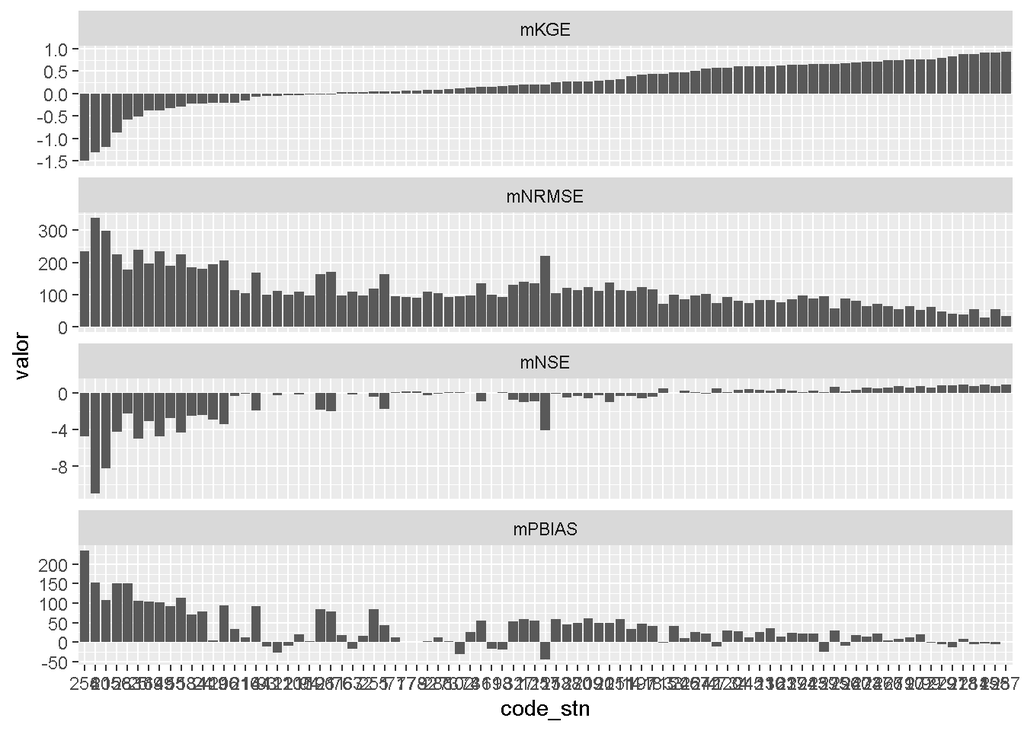

```r
metrics_df %>%
ggplot(aes(x = code_stn, y = valor)) +
  geom_col() +
  facet_wrap(~metric, scales = "free_y", nrow = data.table::uniqueN(metrics_df$metric)) +
  theme(axis.text.x = )
```

Visualização da melhor previsão baseado na métrica KGE.

```r
qnat_posto287 <- pobs_qmly %>%
  sel_station(.,station = 287) %>%
  select(date,qnat_obs,qnat_pred)
```

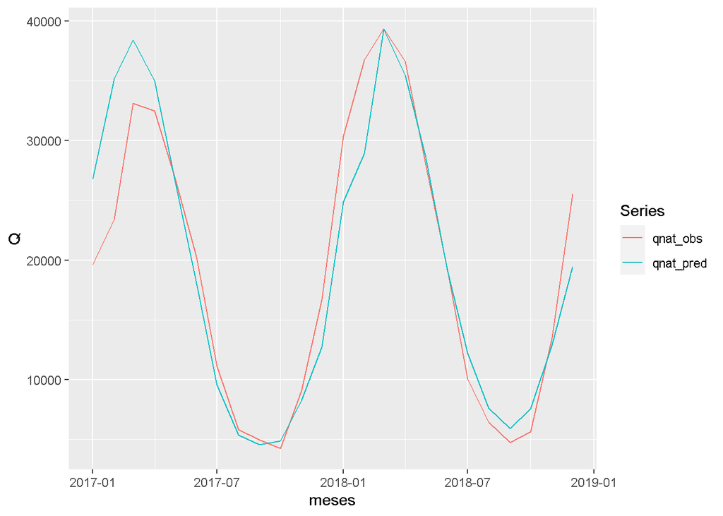

```r
posto287_xts <- xts(qnat_posto287[,c("qnat_obs","qnat_pred")],
                   order.by = as.Date(qnat_posto287[["date"]]))
forecast::autoplot(posto287_xts, facets = FALSE)+
  ylab("Q") +
  xlab("meses") +
  theme(
    strip.background = element_blank(),
    strip.text = element_blank()
  )
```

## Aplicação do ensemble PSF

O pacote PSF emprega o algoritmo de agrupamento `kmeans` usando o método de Hartigan–Wong. Esta técnica gera resultados mais robustos ao variar aleatoriamente os valores iniciais dos centróides dos grupos. Portanto diferentes soluções são obtidas cada vez que a função é executada. Iremos fazer o ensemble do PSF rodando cinco iterações e verificaremos se as previsões médias e as previsões feitas com as modas dos parâmetros `k` e `w` dos modelos são capazes de gerar melhores resultados.

A função `ensemble_psf` é usada para gerar os modelos e suas previsões.

```r
# Modelos e predições resultantes de 5 iterações para cada posto
# start_time <- Sys.time()
# esb_qmly <- train_qmly %>%
#   mutate(
#     models = map(
#       data,
#       ~ ensemble_psf(.x, predict = FALSE)
#     ),
#     preds = map(data, ensemble_psf)
#   )
# end_time <- Sys.time() # ~9 minutos

# saveRDS(esb_qmly, file = here('output', 'esb_qmly.rds'))
# Carrega o modelo
esb_qmly <- readRDS(here("output", "esb_qmly.rds"))
```

A partir dos modelos gerados em cada iteração iremos extrair a moda dos parâmetros críticos para o desempenho das previsões: `k` e `w`. Além disso, calcularemos a média das previsões de cada modelo. A previsão utilizando o PSF sem o ensemble foi incluída para comparação.

```r
pobqmly_esb <- esb_qmly %>%
  mutate(
    # moda dos parâmetros k e w
    modparam_qmly = map(models, get_modpar),
    # previsões médias das iterações
    qnat_mpred = unlist(map(preds, get_mpred),
      recursive = FALSE
    ),
    qnat_pred = map(data,psf_reprod),
    # previsões usando k e w médios
    qnat_modpar = map(
      data, # previsões usando k e w médios
      ~ ensemble_mpar(.x, modparam_qmly)
    )
  ) %>%
  inner_join(.,
    test_qmly,
    by = "code_stn"
  ) %>%
  select(qnat_obs, qnat_mpred, qnat_modpar,qnat_pred) %>%
  unnest(cols = -code_stn)
```

```r
aval_esb <- pobqmly_esb %>%
  summarise(
    KGE_mpred = KGE(sim = qnat_mpred, obs = qnat_obs),
    KGE_modpar = KGE(sim = qnat_modpar, obs = qnat_obs),
    KGE_pred = KGE(sim = qnat_pred, obs = qnat_obs),
    mPBIAS = pbias(sim = qnat_mpred, obs = qnat_obs),
    mNRMSE = nrmse(sim = qnat_mpred, obs = qnat_obs),
    mNSE = mNSE(sim = qnat_mpred, obs = qnat_obs)
  ) %>%
  arrange(-KGE_pred)

(aval_esb)
```

```
#> # A tibble: 87 x 7
#>    code_stn KGE_mpred KGE_modpar KGE_pred mPBIAS mNRMSE  mNSE
#>       <dbl>     <dbl>      <dbl>    <dbl>  <dbl>  <dbl> <dbl>
#>  1      287     0.930      0.937    0.937   -2.4   35.6 0.705
#>  2      295     0.876      0.908    0.908   -6.8   59.6 0.388
#>  3      145     0.908      0.908    0.908   -3.2   28.3 0.771
#>  4      281     0.876      0.876    0.876   -4.7   54.3 0.570
#>  5      278     0.860      0.879    0.875   11.2   40.1 0.639
#>  6      291     0.835      0.806    0.821   -6.9   43.3 0.668
#>  7      279     0.763      0.783    0.791   -8.9   43.2 0.639
#>  8       99     0.811      0.810    0.769   -0.9   58.5 0.530
#>  9      277     0.763      0.763    0.763   20.4   53   0.414
#> 10      190     0.769      0.716    0.760   13.3   62.8 0.495
#> # ... with 77 more rows
```

Verificaremos qual modelo apresentou o KGE superior para um maior número de postos.

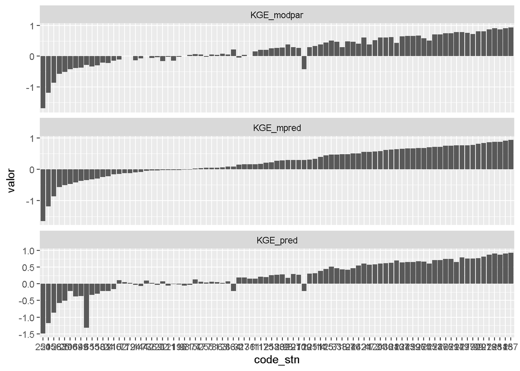

```r
metrics_esb <- aval_esb %>%
  select(code_stn, KGE_mpred, KGE_modpar, KGE_pred) %>%
  mutate(code_stn = factor(code_stn, levels = code_stn[order(KGE_mpred)])) %>%
  # filter(mKGE >= 0.3 | mNSE >= 0.5) %>%
  pivot_longer(
    cols = -c(code_stn),
    names_to = "metric",
    values_to = "valor"
  )

metrics_esb %>%
ggplot(aes(x = code_stn, y = valor)) +
  geom_col() +
  facet_wrap(~metric, scales = "free_y", nrow = data.table::uniqueN(metrics_esb$metric)) +
  theme(axis.text.x = )
```

```r
bestKGE_esb <- metrics_esb %>%
  group_by(code_stn) %>%
  filter(valor >= 0.3) %>%
  slice(which.max(valor)) %>%
  ungroup() %>%
  count(metric)

(bestKGE_esb)
```

```
#> # A tibble: 3 x 2
#>   metric         n
#>   <chr>      <int>
#> 1 KGE_modpar     9
#> 2 KGE_mpred     24
#> 3 KGE_pred       6
```

A média das previsões das cinco iterações forneceram o melhor resultado de acordo com métrica KGE. No entanto, para avaliar se há vantagem em usar este modelo vamos verificar se a diferença foi significativa em relação as previsões feitas sem o ensemble.

```r
difb_esbKGE <- metrics_esb %>%
  group_by(code_stn) %>%
  filter(valor >= 0.3) %>%
  mutate(
    difb_KGE = max(valor) - min(valor)
  ) %>%
  slice(which.max(valor)) %>%
  arrange(-valor)

(difb_esbKGE)
```

```
#> # A tibble: 39 x 4
#> # Groups:   code_stn [39]
#>    code_stn metric     valor difb_KGE
#>    <fct>    <chr>      <dbl>    <dbl>
#>  1 287      KGE_modpar 0.937  0.00701
#>  2 295      KGE_modpar 0.908  0.0323
#>  3 145      KGE_mpred  0.908  0
#>  4 278      KGE_modpar 0.879  0.0182
#>  5 281      KGE_mpred  0.876  0
#>  6 291      KGE_mpred  0.835  0.0296
#>  7 99       KGE_mpred  0.811  0.0414
#>  8 279      KGE_pred   0.791  0.0288
#>  9 294      KGE_modpar 0.786  0.138
#> 10 190      KGE_mpred  0.769  0.0522
#> # ... with 29 more rows
```

```r
(summary(difb_esbKGE$difb_KGE))
```

```
#>    Min. 1st Qu.  Median    Mean 3rd Qu.    Max.
#> 0.00000 0.00000 0.01822 0.04046 0.04813 0.26557
```

## Validação cruzada aplicada ao posto 287

A validação cruzada é um método bastante utilizado não só para obter uma estimativa robusta do desempenho de um modelo, mas também para selecionar os melhores hiperparâmetros, isto é, os parâmetros que são definidos antes de treinar um modelo. Iremos aplicar este método para a série hidrológica do posto que obtivemos o melhor desempenho utilizando a técnica de previsão PSF. Além de obter uma estimativa mais robusta do desempenho do algoritmo para este posto, também iremos selecionar os valores ótimos para os parâmetros `k` e `w`.

```r
qnatmly_287 <- qnat_mly %>%
  sel_station(.,287) %>%
  unnest() %>%
  ungroup() %>%
  select(date,qnat_obs)
summary(qnatmly_287)
```

```
#>       date               qnat_obs
#>  Min.   :1968-01-01   Min.   : 2788
#>  1st Qu.:1980-09-23   1st Qu.: 8087
#>  Median :1993-06-16   Median :17365
#>  Mean   :1993-06-16   Mean   :18972
#>  3rd Qu.:2006-03-08   3rd Qu.:28285
#>  Max.   :2018-12-01   Max.   :54435
```

Iremos separar os dados em um conjunto de treinamento e outro de teste, tal como feito anteriormente, só que dessa vez realizaremos previsões para um horizonte de 12 meses. A ideia é usar o conjunto de dados de teste após a validação cruzada para avaliar o desempenho das previsões utilizando os parâmetros selecionados.

```r
# Dados de treinamento sem o último ano
train287_qmly <- get_traindt(qnatmly_287,yrs = 1)
summary(train287_qmly)
```

```
#>       date               qnat_obs
#>  Min.   :1968-01-01   Min.   : 2788
#>  1st Qu.:1980-06-23   1st Qu.: 8087
#>  Median :1992-12-16   Median :17287
#>  Mean   :1992-12-15   Mean   :18924
#>  3rd Qu.:2005-06-08   3rd Qu.:28259
#>  Max.   :2017-12-01   Max.   :54435
```

```r
# Dados para avaliação do PSF
test287_qmly <- get_testdt(qnatmly_287,n = 12)
summary(test287_qmly)
```

```
#>       date               qnat_obs
#>  Min.   :2018-01-01   Min.   : 4749
#>  1st Qu.:2018-03-24   1st Qu.: 9135
#>  Median :2018-06-16   Median :22404
#>  Mean   :2018-06-16   Mean   :21351
#>  3rd Qu.:2018-09-08   3rd Qu.:31931
#>  Max.   :2018-12-01   Max.   :39355
```

Os dados de treinamento serão divididos em duas partições: treinamento e validação. Nessa forma de divisão teremos a partição de validação sempre a frente da partição de treinamento. A função `time_series_cv` do pacote `timetk` nos permite criar uma plano de amostragem começando com as observações mais atuais da série. A partir do parâmetro `assess` definimos que a partição da validação deverá ser formada de 12 meses de observações e o parâmetro `skip` fornece o número de meses que serão pulados em cada divisão. O número de divisões é selecionado pelo parâmetro `slice_limit` e um número não fixo da janela foi definido através do parâmetro `cumulative`. Aumentando o número de divisões teremos uma avaliação mais robusta do modelo, porém há um maior custo computacional.

```r
resample_qmly287 <- time_series_cv(
  data = train287_qmly,
  assess = "12 months",
  skip = "36 months",
  cumulative = TRUE,
  slice_limit = 15
)
```

```
#> Using date_var: date
```

```r
# Visualização do plano de amostragem
# resample_qmly287 %>%
#  plot_time_series_cv_plan(date,qnat_obs, .interactive = FALSE)
```

Aplicaremos o PSF a todas as divisões do conjunto de treinamento para obter uma avaliação robusta do desempenho do modelo. Além disso disso, adicionaremos uma coluna com as previsões usando a média dos parâmetros `k` e `w`.

```r
qmly287_slices <- resample_qmly287 %>%
  tk_time_series_cv_plan() %>%
  nest(date, qnat_obs) %>%
  pivot_wider(names_from = .key, values_from = data)
```

```r
# Previsões usando um horizonte de 12 meses
cv287_qmly <- qmly287_slices %>%
  mutate(
    qnat_pred = map(
      training,
      ~ psf_reprod(.x, n = 12)
    ),
    model = map(
      training,
      ~ psf_reprod(.x, n = 12, predict = FALSE)
    ),
    cvparams = map(model, get_cvpar)
  )


# Média dos parâmetros k e w (2 e 3)
cvm_params <- round(Reduce("+", cv287_qmly[["cvparams"]])
/ length(cv287_qmly[["cvparams"]]), 0)

# Adicionando  coluna com as  prevs usando parâmetros médios
cv287_qmly <- cv287_qmly %>%
  mutate(qnatmpar_pred = map(
    training,
    ~ psf_cvparam(.x, n = 12, params = cvparams)
  ))
```

Iremos comparar o desempenho do modelo com e sem a seleção dos parâmetros pela média.

```r
avalcv_m287 <- cv287_qmly %>%
  select(-c("model", "training", "cvparams")) %>%
  group_by(.id) %>%
  unnest() %>%
  summarise(
    KGEpred = KGE(sim = qnat_pred, obs = qnat_obs),
    KGEmpar = KGE(sim = qnatmpar_pred, obs = qnat_obs)
  )  %>%
  mutate(.id = factor(.id, levels = .id[order(KGEmpar)])) %>%
  pivot_longer(
    cols = -c(.id),
    names_to = "metric",
    values_to = "valor"
  )
```

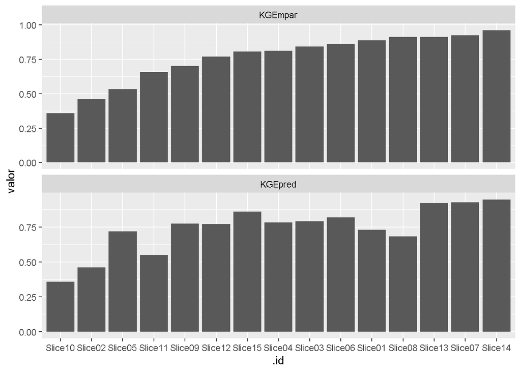

```r
avalcv_m287 %>%
ggplot(aes(x = .id, y = valor)) +
  geom_col() +
  facet_wrap(~metric, scales = "free_y", nrow = data.table::uniqueN(avalcv_m287$metric)) +
  theme(axis.text.x = )
```

```r
avalcv_m287 %>%
  group_by(metric) %>%
  summarise(
    valor = mean(valor)
  )
```

```
#> # A tibble: 2 x 2
#>   metric  valor
#>   <chr>   <dbl>
#> 1 KGEmpar 0.760
#> 2 KGEpred 0.739
```

Verificaremos o desempenho do modelo utilizando os parâmetros médios no conjunto de dados de teste.

```r
# Previsões feitas com os parâmetros médios
pcv287_mpar <- psf_cvparam(train287_qmly,
  n = 12,
  params = cvm_params
)
# Previsões sem a seleção dos parâmetros
preds287_qmly <- psf_reprod(train287_qmly, n = 12)

# Previsões e observações
pobs287cv_qmly <- mutate(test287_qmly,
  qnatcv_pred = NA,
  qnat_pred = NA,
  qnatcv_pred = replace(qnatcv_pred,
    values = pcv287_mpar
  ),
  qnat_pred = replace(qnat_pred,
    values = preds287_qmly
  )
)

avalcvmpar_287 <- pobs287cv_qmly %>%
  summarise(
    KGE = KGE(sim = qnat_pred, obs = qnat_obs),
    KGEcv = KGE(sim = qnatcv_pred, obs = qnat_obs)
  )
(avalcvmpar_287)
```

```
#> # A tibble: 1 x 2
#>     KGE KGEcv
#>   <dbl> <dbl>
#> 1 0.803 0.824
```

Observamos, baseado na métrica KGE, uma pequena melhora no modelo utilizando a seleção dos parâmetros pela média.

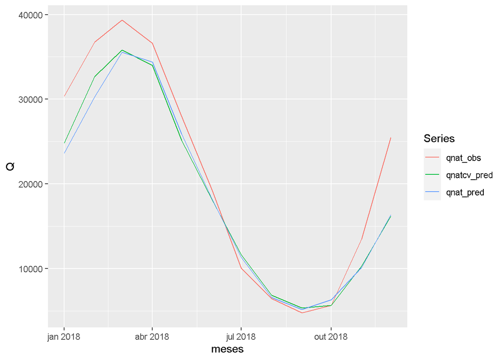

```r
posto287cv_xts <- xts(pobs287cv_qmly[,c("qnat_obs","qnatcv_pred","qnat_pred")],
                   order.by = as.Date(pobs287cv_qmly[["date"]]))
forecast::autoplot(posto287cv_xts, facets = FALSE)+
  ylab("Q") +
  xlab("meses") +
  theme(
    strip.background = element_blank(),
    strip.text = element_blank()
  )
```